# Praca domowa nr 12

Paweł Pollak

## Opis

W ramach tej pracy domowej została wykonana poprawa i rozwinięcie pracy domowej nr 5 wykonanej przez Karola Szczawińskiego ([praca](https://cdn.rawgit.com/szczawinskik/TechnikiWizualizacjiDanych2017/f9a1f114b99ed0ced73cc3c539f40c162a0e1d5e/PraceDomowe/PD_05/karol_szczawinski/karol_szczawinski_PD_05.html) i [pull request](https://github.com/pbiecek/TechnikiWizualizacjiDanych2017/pull/99)).

- zmiana orientacji wykresów (wg uwag)
- przeprowadzenie dyskusji (wg uwag)
- poprawiony wygląd wykresów
- wprowadzanie innego sposobu przestawienia danych

## Wykresy

### Zwykły słupkowy

W tym przypadku, nie zostały wykonane znaczące zmiany.

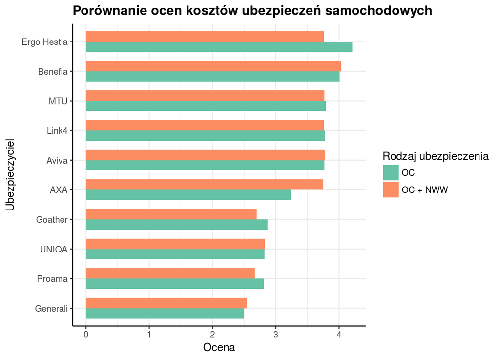

Wykres bez zmian:

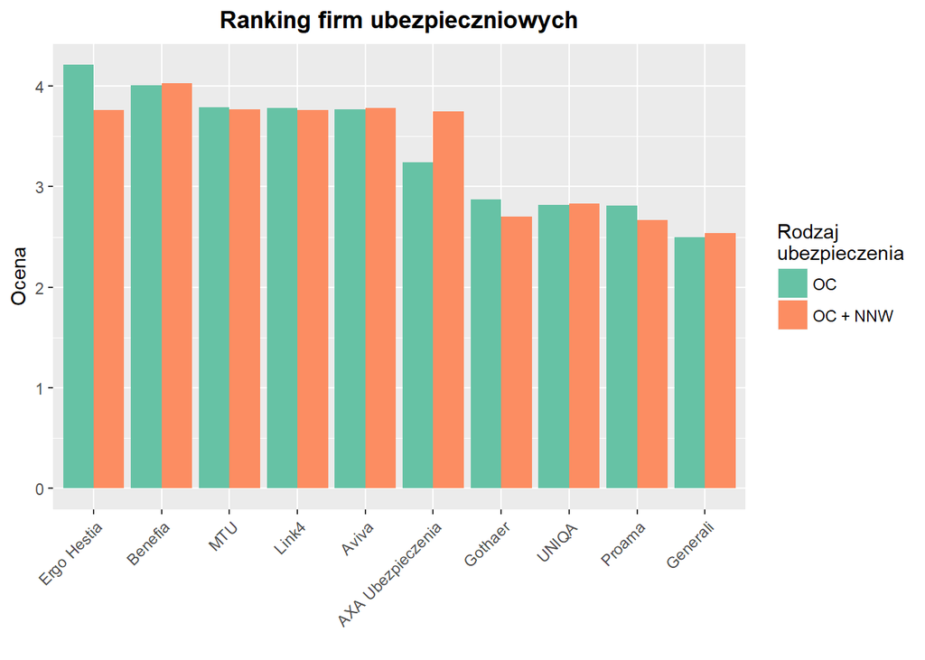

### Słupkowy “liniowy”

W oryginale kolor *OC + NWW* zawsze przykrywał całą linię. Niepotrzebnie wprowadzało to przewagę tego koloru, sugerując, że to *OC + NWW* ma zawsze lepszą ocenę.

Po poprawie, jedynie część różniąca poszczególne oceny ma kolor odpowiadający rodzajowi ubezpieczenia.

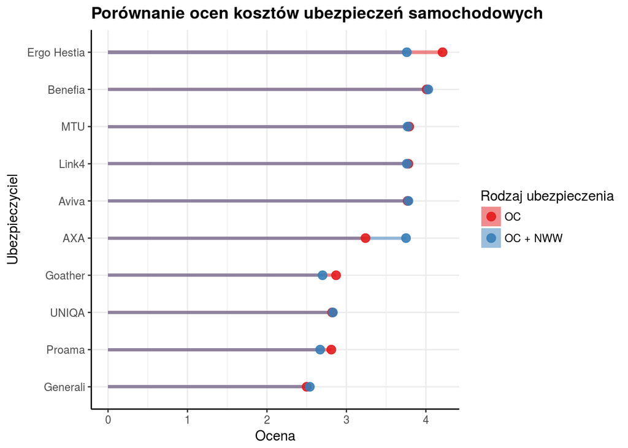

Wykres bez zmian:

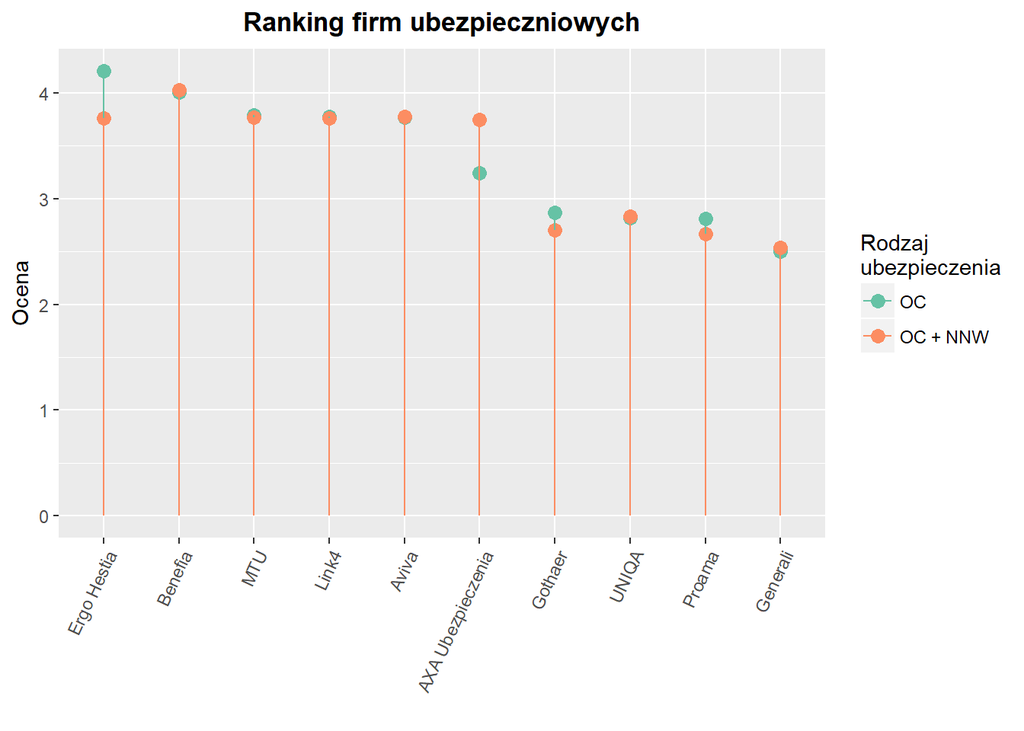

### Nakładające się słupki

Można przedstawić te dane kładąc nacisk na ogólnie najlepszą ocenę ubezpieczalni (*OC* lub *OC + NWW*). Jednocześnie nie tracąc informacji o tym, która ocena w danej ubezpieczalni jest wyższa.

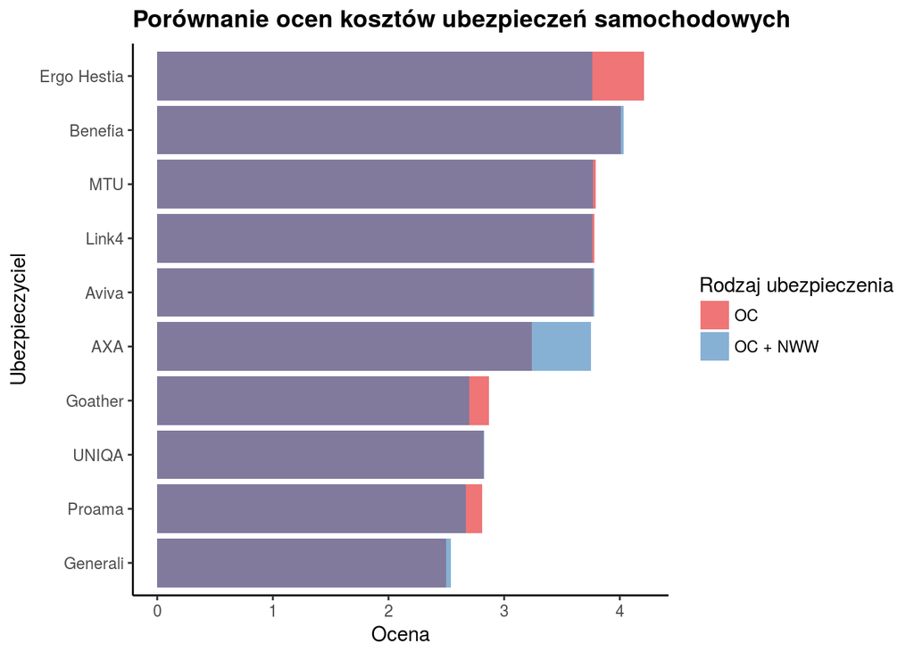

W wykresach zostało również usunięte tło i został zmieniony wygląd osi i tytuły.

## Dyskusja

Użycie każdego z tych wykresów może być w pewien sposób usprawiedliwione i ma swoje zalety.

1. Pierwszy wykres słupkowy (ze słupkami tego samego ubezpieczyciela obok siebie) jest najłatwiejszy do zrozumienia, najbardziej naturalny. Kładzie nacisk na fakt, że istnieją dwa rodzaje ubezpieczeń. Jednak znika gdzieś przekaz, który ubezpieczyciel ma ogólnie najlepszą ofertę, ponieważ słupki bardzo “skaczą”.
2. Drugi wykres z cienkimi słupkami jest bliższy ostatniemu wykresowi niż pierwszemu. Tak naprawdę, po dodaniu wspólnego koloru dla części wspólnej słupków rożni się od niego grubością słupków i obecnością kropek. Jednak w na pierwszy rzut oka wydaje się zupełnie inny. Jest najmniej intuicyjny ze wszystkich, jednak może to by być związane z tym, że rzadko się widzi takie wykresy. Zatem może kogoś zaciekawić. Dzięki kropkom (i w nowej wersji kolorom słupków) widać wyraźnie gdzie różnice pomiędzy oceną oferty *OC* i *OC + NWW* są większe.
3. Trzeci wykres (podobnie jak drugi) będzie przydatny, gdy komuś zależy na położenie nacisku na ogólnie najwyższą wartość oceny ubezpieczyciela albo na różnice w ocenie w zależności od rodzaju oferty. Jednak pokazując jedną z tych cech, nie tracimy na jakości przedstawienia drugiej.

Widoczna jest ogólna wysokość słupka i to czy (i o ile) jedna z ocen różni się od drugiej w zależności od rodzaju. Od razu widać gdzie te różnice są większe, a gdzie nie ma ich prawie w ogóle. W przypadku pierwszego wykresu, mimo że takie informacje są na nim również zawarte, to nie rzucają się aż tak w oczy.

Podsumowując, najrozsądniejsze wydaje się użycie pierwszego lub trzeciego wykresu w zależności od tego na co ma zostać położony nacisk.